# PaleoACES analysis report

# 2. Climate

Modern climate is CHELSA V2.1 monthly climate in a survey-specific window for every plot (`R/pipeline/04_modern_climate.R`); Holocene climate is CHELSA-TraCE21k at each lake and century (`R/pipeline/07_paleo_climate.R`).

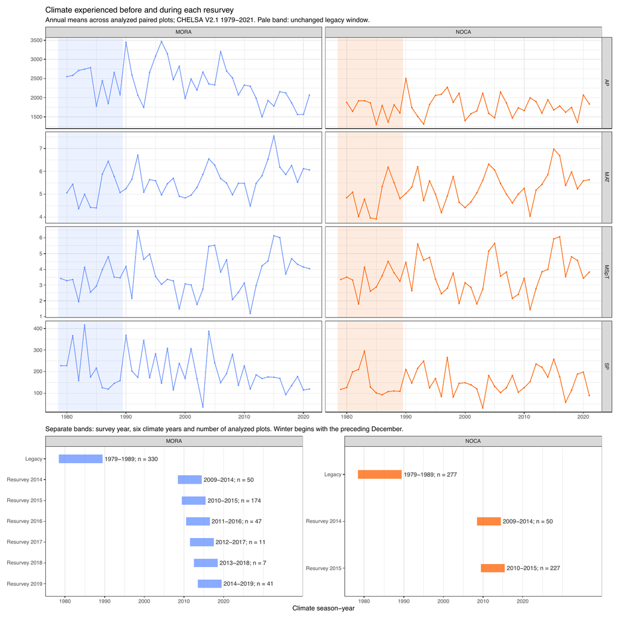

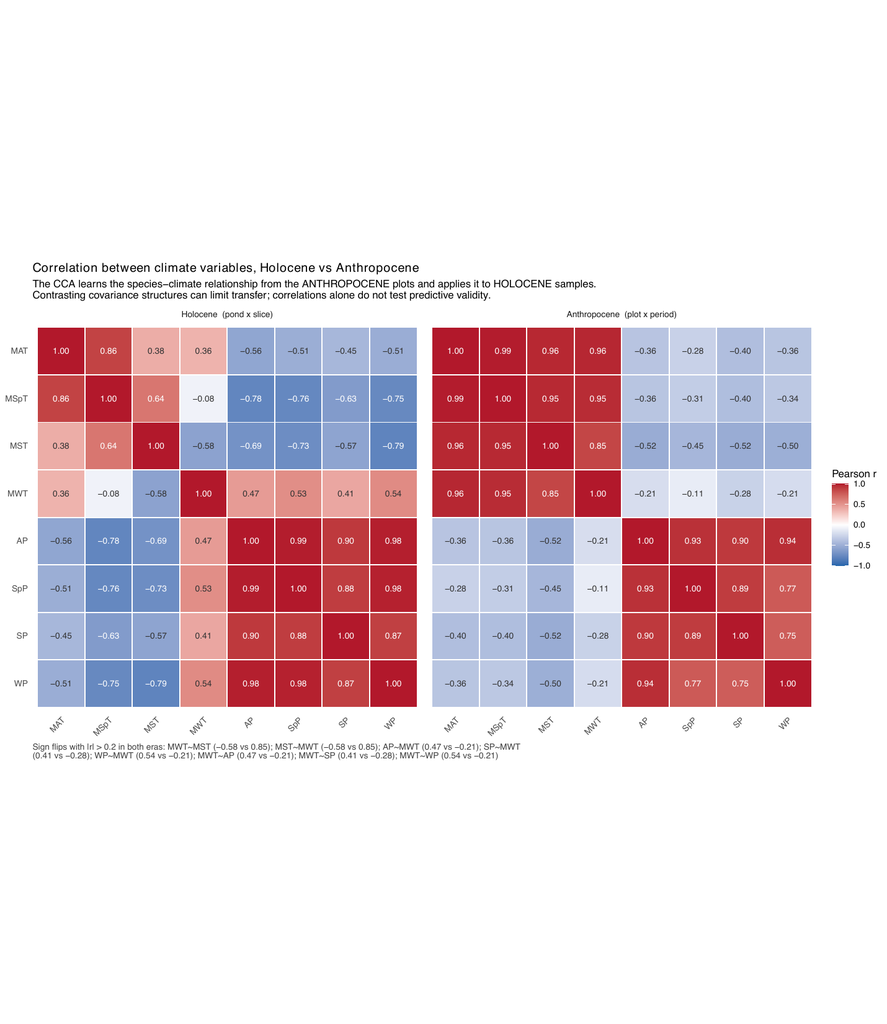

**Fig. S4. Correlations among climate variables during the Holocene and Anthropocene.** Pearson correlation coefficients (r) were calculated across lake locations and 100-year climate intervals for the Holocene (CHELSA-TraCE21k, left) and across vegetation plots and survey periods for the Anthropocene (CHELSA v2.1, right). Red indicates positive correlations and blue indicates negative correlations, with numerical values showing Pearson’s r. Climate variables include mean annual (MAT), spring (MSpT), summer (MST), and winter (MWT) temperature, and annual (AP), spring (SpP), summer (SP), and winter (WP) precipitation. Spring corresponds to March–May, summer to June–August, and winter to December–February.

**Choice of CCA constraints.** Candidate variables are screened by their correlations (Fig. S4) and by their variance inflation in the fitted CCA, keeping one temperature and one precipitation variable. With the four seasonal variables MSpT, MWT, SP and WP, the two temperatures had variance inflation factors near 30 and opposite-signed coefficients that are not identifiable. The CCA is therefore constrained by spring temperature, the temperature that changes most through the Holocene, and summer precipitation. Figures in the CCA plane are rotated rigidly by the varimax angle so that the two arrows lie along the axes; distances and angles, and therefore every tracking metric, are unchanged by the rotation (decision of 2026-11-09 in **Decisions →** 10_decisions). The constraints of this build:

| Variable | Label | VIF | CCA1 score | CCA2 score |
| --- | --- | --- | --- | --- |
| MSpT | Spring temperature | 1.08 | 0.53 | -0.09 |
| SP | Summer precipitation | 1.08 | -0.26 | -0.34 |

<sub>Table file: cca_constraint_vif.csv</sub>

**Climate details →** 02_climate (survey windows, TraCE21k against V2.1, full correlation tables).

# Appendix S1. Construction of the Holocene age–depth models

### S1.1 Why an age–depth model was required

The macrofossils are measured at known depths in a sediment core, but depth itself does not provide an age. Sediment does not necessarily accumulate at a constant rate: for example, 1 cm of sediment can represent relatively few years during rapid accumulation and many more years during slow accumulation. Chronological control is available only at selected depths, through radiocarbon dates, dated volcanic deposits, ²¹⁰Pb dating, or other independently dated horizons. We therefore required an age–depth model to estimate the calendar age of every depth between these dated points and, importantly, to quantify uncertainty in those estimated ages.

We used the rbacon R package, which reconstructs sediment accumulation histories within a Bayesian framework (Blaauw & Christen 2011). Rather than drawing a single line through the dated horizons, Bacon estimates many age–depth histories that are compatible with the chronological evidence and assumptions about sediment accumulation. The distribution of these histories represents the posterior chronological uncertainty shown in Fig. S5.

### S1.2 Chronological controls and radiocarbon calibration

For each core, we assembled chronological controls for which both sediment depth and age information were available (Table S1.1). For MORA, these consisted of the core surfaces, seven radiocarbon dates from Jay Bath and Log Wallow, dated volcanic tephra horizons, and a basal radiocarbon age for Reflection Pond. Reflection Pond contained no radiocarbon dates of its own and was therefore constrained by the core surface, tephra horizons, and this basal control. For Panther Potholes, we reproduced the chronology archived in the Neotoma database using the core surface, five ²¹⁰Pb ages, six Accelerator Mass Spectrometry (AMS) radiocarbon dates, and three tephra horizons. We used the corrected control depths archived in Neotoma rather than the depths reported in Prichard et al. (2009), which contain documented depth errors.

Radiocarbon ages are expressed in ¹⁴C years and cannot be treated directly as calendar ages because atmospheric ¹⁴C concentrations have varied through time. We therefore supplied radiocarbon ages and their laboratory errors as uncalibrated dates (cc = 1), which Bacon calibrated against the IntCal20 Northern Hemisphere calibration curve (Reimer et al. 2020). This converts each radiocarbon measurement into a probability distribution of plausible calendar ages. Controls already expressed in calendar years, including the core surfaces and tephra ages, were supplied directly (cc = 0) and were not calibrated.

The seven MORA radiocarbon ages and their laboratory errors were taken directly from Dunwiddie (1986). For all other chronological controls, the source and interpretation of the assigned age uncertainty are reported explicitly in Table S1.1. The Reflection Pond basal control is the mean of the two basal radiocarbon ages of Jay Bath (QL-1704) and Log Wallow (QL-1728), 6015 ± 110 ¹⁴C yr BP with the larger of the two laboratory errors, following P. Dunwiddie’s advice that the three basins share the same basal age (pers. comm.).

For Panther Potholes, the five ²¹⁰Pb ages were derived using a Constant Rate of Supply (CRS) model. We retained the error values used in the archived Gavin chronology for the primary model; however, these values correspond numerically to the ²¹⁰Pb activity uncertainties reported by Prichard et al. (2009), rather than to independently estimated age uncertainties in years. We therefore evaluated this uncertainty specification in a separate sensitivity analysis described below.

**Table S1.1. Chronological controls used in the four Bayesian age–depth models.** For cc = 1, the entered age is an uncalibrated ¹⁴C age calibrated with IntCal20. For cc = 0, the entered age is already in calibrated years before present (cal yr BP; present = A.D. 1950).

| Site | Core | Chronological control | Depth (cm) | Age entered ± error | Bacon treatment | Age source | Uncertainty source |
| --- | --- | --- | --- | --- | --- | --- | --- |
| MORA | Jay Bath | Core surface | 0 | −31.5 ± 10 cal yr BP | cc = 0 | Coring date, 1981–1982 | Assumed ±10 yr to account for uncertainty in recovery of the sediment–water interface |
| MORA | Jay Bath | MSH-W tephra | 22 | 470 ± 10 cal yr BP | cc = 0 | Yamaguchi 1983; Walsh et al. 2017 | Assumed ±10 yr around the tree-ring-dated eruption age; no published statistical age error |
| MORA | Jay Bath | QL-1729 | 39.5 | 1320 ± 30 ¹⁴C yr BP | cc = 1, IntCal20 | Dunwiddie 1986 | Published laboratory error |
| MORA | Jay Bath | MR-C tephra | 62 | 2250 ± 100 cal yr BP | cc = 0 | Mullineaux 1974; Walsh et al. 2017 | Assumed ±100 yr; no published statistical age error |
| MORA | Jay Bath | QL-1730 | 70 | 2920 ± 60 ¹⁴C yr BP | cc = 1, IntCal20 | Dunwiddie 1986 | Published laboratory error |
| MORA | Jay Bath | MSH-Y tephra, upper boundary | 87 | 3650 ± 100 cal yr BP | cc = 0 | Mullineaux 1974; Walsh et al. 2017 | ±100 yr derived approximately from radiocarbon dates bracketing the eruption age (bracket half-width ≈103 yr; Mullineaux 1996) |
| MORA | Jay Bath | MSH-Y tephra, lower boundary | 105 | 3650 ± 100 cal yr BP | cc = 0 | Mullineaux 1974; Walsh et al. 2017 | Same uncertainty as upper boundary; both depths represent the same instantaneous tephra deposit |
| MORA | Jay Bath | Beta-6332 | 124.5 | 3740 ± 80 ¹⁴C yr BP | cc = 1, IntCal20 | Dunwiddie 1986 | Published laboratory error |
| MORA | Jay Bath | MR-F tephra | 142 | 5740 ± 100 cal yr BP | cc = 0 | Mullineaux 1974; Walsh et al. 2017 | Assumed ±100 yr; no published statistical age error |
| MORA | Jay Bath | QL-1704 | 152.25 | 6050 ± 110 ¹⁴C yr BP | cc = 1, IntCal20 | Dunwiddie 1986 | Published laboratory error |
| MORA | Log Wallow | Core surface | 0 | −31.5 ± 10 cal yr BP | cc = 0 | Coring date, 1981–1982 | Assumed ±10 yr to account for uncertainty in recovery of the sediment–water interface |
| MORA | Log Wallow | MSH-W tephra | 22 | 470 ± 10 cal yr BP | cc = 0 | Yamaguchi 1983; Walsh et al. 2017 | Assumed ±10 yr around the tree-ring-dated eruption age; no published statistical age error |
| MORA | Log Wallow | QL-1726 | 29 | 1650 ± 80 ¹⁴C yr BP | cc = 1, IntCal20 | Dunwiddie 1986 | Published laboratory error |
| MORA | Log Wallow | MSH-Y tephra, upper boundary | 40 | 3650 ± 100 cal yr BP | cc = 0 | Mullineaux 1974; Walsh et al. 2017 | ±100 yr derived approximately from radiocarbon dates bracketing the eruption age (bracket half-width ≈103 yr; Mullineaux 1996) |
| MORA | Log Wallow | MSH-Y tephra, lower boundary | 98 | 3650 ± 100 cal yr BP | cc = 0 | Mullineaux 1974; Walsh et al. 2017 | Same uncertainty as upper boundary; both depths represent the same instantaneous tephra deposit |
| MORA | Log Wallow | MR-F tephra | 116 | 5740 ± 100 cal yr BP | cc = 0 | Mullineaux 1974; Walsh et al. 2017 | Assumed ±100 yr; no published statistical age error |
| MORA | Log Wallow | QL-1727 | 117 | 4900 ± 80 ¹⁴C yr BP | cc = 1, IntCal20 | Dunwiddie 1986 | Published laboratory error |
| MORA | Log Wallow | QL-1728 | 140 | 5980 ± 60 ¹⁴C yr BP | cc = 1, IntCal20 | Dunwiddie 1986 | Published laboratory error |
| MORA | Reflection Pond | Core surface | 0 | −31.5 ± 10 cal yr BP | cc = 0 | Coring date, 1981–1982 | Assumed ±10 yr to account for uncertainty in recovery of the sediment–water interface |
| MORA | Reflection Pond | MSH-W tephra | 10 | 470 ± 10 cal yr BP | cc = 0 | Yamaguchi 1983; Walsh et al. 2017 | Assumed ±10 yr around the tree-ring-dated eruption age; no published statistical age error |
| MORA | Reflection Pond | MR-C tephra | 26 | 2250 ± 100 cal yr BP | cc = 0 | Mullineaux 1974; Walsh et al. 2017 | Assumed ±100 yr; no published statistical age error |
| MORA | Reflection Pond | MSH-Y tephra, upper boundary | 45 | 3650 ± 100 cal yr BP | cc = 0 | Mullineaux 1974; Walsh et al. 2017 | ±100 yr derived approximately from radiocarbon dates bracketing the eruption age (bracket half-width ≈103 yr; Mullineaux 1996) |
| MORA | Reflection Pond | MSH-Y tephra, lower boundary | 64 | 3650 ± 100 cal yr BP | cc = 0 | Mullineaux 1974; Walsh et al. 2017 | Same uncertainty as upper boundary; both depths represent the same instantaneous tephra deposit |
| MORA | Reflection Pond | MR-F tephra | 82 | 5740 ± 100 cal yr BP | cc = 0 | Mullineaux 1974; Walsh et al. 2017 | Assumed ±100 yr; no published statistical age error |
| MORA | Reflection Pond | Basal sediment, mean of QL-1704 and QL-1728 | 90 | 6015 ± 110 ¹⁴C yr BP | cc = 1, IntCal20 | Dunwiddie 1986; P. Dunwiddie, pers. comm. | Larger of the two laboratory errors (±110 yr), allowing for transfer of the Jay Bath and Log Wallow basal age to Reflection Pond |
| NOCA | Panther Potholes | Core surface | 0.5 | −49 ± 1 cal yr BP | cc = 0 | Gavin 2021 Neotoma chronology; coring year 1999 | ±1 yr retained from the archived Gavin chronology |
| NOCA | Panther Potholes | ²¹⁰Pb CRS age | 7 | −36.7; error entered = 3.47 | cc = 0 | Prichard et al. 2009; Gavin 2021 | Inherited Gavin value; 3.47 is numerically the published ²¹⁰Pb activity uncertainty in DPM g⁻¹, not a verified age error in years |
| NOCA | Panther Potholes | ²¹⁰Pb CRS age | 14 | −9; error entered = 1.15 | cc = 0 | Prichard et al. 2009; Gavin 2021 | Inherited Gavin value; 1.15 is numerically the published ²¹⁰Pb activity uncertainty in DPM g⁻¹, not a verified age error in years |
| NOCA | Panther Potholes | ²¹⁰Pb CRS age | 21 | 12; error entered = 0.72 | cc = 0 | Prichard et al. 2009; Gavin 2021 | Inherited Gavin value; 0.72 is numerically the published ²¹⁰Pb activity uncertainty in DPM g⁻¹, not a verified age error in years |
| NOCA | Panther Potholes | ²¹⁰Pb CRS age | 28 | 21; error entered = 0.74 | cc = 0 | Prichard et al. 2009; Gavin 2021 | Inherited Gavin value; 0.74 is numerically the published ²¹⁰Pb activity uncertainty in DPM g⁻¹, not a verified age error in years |
| NOCA | Panther Potholes | ²¹⁰Pb CRS age | 35 | 36; error entered = 0.77 | cc = 0 | Prichard et al. 2009; Gavin 2021 | Inherited Gavin value; 0.77 is numerically the published ²¹⁰Pb activity uncertainty in DPM g⁻¹, not a verified age error in years |
| NOCA | Panther Potholes | Beta-172005, conifer seed | 214 | 1950 ± 50 ¹⁴C yr BP | cc = 1, IntCal20 | Prichard et al. 2009 | Published laboratory error |
| NOCA | Panther Potholes | MSH-P tephra | 305.5 | 2620 ± 70 cal yr BP | cc = 0 | Gavin 2021 Neotoma chronology | Age and ±70-yr uncertainty retained from the archived chronology |
| NOCA | Panther Potholes | Beta-169623, seed | 363 | 3260 ± 40 ¹⁴C yr BP | cc = 1, IntCal20 | Prichard et al. 2009 | Published laboratory error |
| NOCA | Panther Potholes | Beta-169624, pollen cone | 389 | 3520 ± 40 ¹⁴C yr BP | cc = 1, IntCal20 | Prichard et al. 2009 | Published laboratory error |
| NOCA | Panther Potholes | MSH-Y tephra | 401 | 3660 ± 65 cal yr BP | cc = 0 | Gavin 2021 Neotoma chronology | Age and ±65-yr uncertainty retained from the archived chronology |
| NOCA | Panther Potholes | Beta-169207, pollen cone | 479 | 4500 ± 40 ¹⁴C yr BP | cc = 1, IntCal20 | Prichard et al. 2009 | Published laboratory error |
| NOCA | Panther Potholes | Mazama tephra | 629 | 7633 ± 25 cal yr BP | cc = 0 | Gavin 2021 Neotoma chronology; Egan et al. 2015 | Age and ±25-yr uncertainty retained from the archived chronology |
| NOCA | Panther Potholes | Beta-169208, seed | 678 | 7330 ± 40 ¹⁴C yr BP | cc = 1, IntCal20 | Prichard et al. 2009 | Published laboratory error |
| NOCA | Panther Potholes | Beta-169625, Pinus contorta needles | 864 | 9370 ± 40 ¹⁴C yr BP | cc = 1, IntCal20 | Prichard et al. 2009 | Published laboratory error |

<sub>Table file: table_S1_1_chronological_controls.csv</sub>

### S1.3 Bayesian age–depth models

We fitted each core independently with Bacon using the settings summarized in Table S1.2. Bacon divided each sediment core into 5-cm sections and estimated an accumulation time, in yr cm⁻¹, for each section. Accumulation times were allowed to differ among sections but were correlated between neighbouring sections through the model’s memory parameter. The chronological controls in Table S1.1 were then used to update these prior expectations and generate the posterior age–depth chronology shown in Fig. S5.

The three MORA cores were modelled using the same accumulation and memory priors. Panther Potholes instead retained the settings of the archived Bacon chronology in the Neotoma database so that our model reproduced the published chronology while providing the complete posterior age–depth draws required for subsequent analyses. All runs are seeded (seed 42).

**Table S1.2. rbacon parameters used to construct the age–depth models.**

| rbacon argument | What it controls | MORA | Panther Potholes | Rationale |
| --- | --- | --- | --- | --- |
| cc, cc1 | Determines whether a date requires radiocarbon calibration and which calibration curve is used | cc=1, cc1=“IntCal20” for ¹⁴C dates; cc=0 for calendar-age controls | Same | Northern Hemisphere terrestrial ¹⁴C dates were calibrated with IntCal20; already calendar-dated controls were not recalibrated |
| thick | Thickness of the sediment sections for which accumulation rates are estimated | 5 cm | 5 cm | Standard Bacon section thickness; for Panther Potholes this value reproduced the archived Gavin chronology |
| acc.mean | Mean of the prior distribution for accumulation time, in yr cm⁻¹ | 50 | 10 | MORA cores accumulate substantially more slowly; 10 yr cm⁻¹ reproduces the Gavin chronology and is close to the approximately 12.8 yr cm⁻¹ reported for Panther Potholes |
| acc.shape | Shape of the gamma prior around acc.mean; larger values impose a more concentrated accumulation prior | 1.5 | 1.5 | Broad rbacon default retained for MORA and Gavin setting retained for Panther Potholes |
| mem.mean | Prior mean dependence between accumulation rates in adjacent sediment sections | 0.5 | 0.7 | rbacon default retained for MORA; Gavin setting retained for Panther Potholes |
| mem.strength | Strength of the prior around mem.mean; larger values impose the assumed memory more strongly | 10 | 10 | Broad rbacon default retained for MORA and Gavin setting retained for Panther Potholes |
| slump | Depth intervals treated as effectively instantaneous accumulation rather than gradual sedimentation | Jay Bath: 87–105 cm; Log Wallow: 40–98 cm; Reflection Pond: 45–64 cm | 303–308, 396–406, and 623–635 cm | Prevents thick tephra deposits from being interpreted as long periods of sediment accumulation |
| normal, t.a, t.b | Distribution used to accommodate chronological-control scatter and potential outlying dates | FALSE, 3, 4 | FALSE, 15, 16 | rbacon default robust t-distribution retained for MORA; Gavin settings retained for Panther Potholes |
| ssize | Number of MCMC iterations retained for the posterior | 4,000 | 10,000 | Default sampling was retained for MORA; Panther Potholes required the larger value for adequate MCMC mixing and reproduction of the archived chronology |
| prob | Posterior interval reported for the chronology | 0.95 | 0.95 | Ages are summarized with 95% posterior intervals |
| d.max | Maximum core depth included in the model | Jay Bath: 153 cm; no manual extension for Log Wallow or Reflection Pond | 870 cm | Jay Bath was extended to 153 cm to retain its deepest macrofossil sample; Panther Potholes retained the Gavin model extent |

<sub>Table file: table_S1_2_rbacon_parameters.csv</sub>

The thick volcanic deposits required one additional treatment. The MSH-Y tephra was represented as an instantaneous depositional interval in all three MORA cores, including the 58-cm interval at Log Wallow containing both primary and redeposited Y tephra. At Panther Potholes, the MSH-P, MSH-Y, and Mazama tephra intervals were treated in the same way. Bacon therefore removed these intervals while estimating gradual sediment accumulation and reinserted them without adding elapsed time. These intervals are shown as vertical grey bands in Fig. S5.

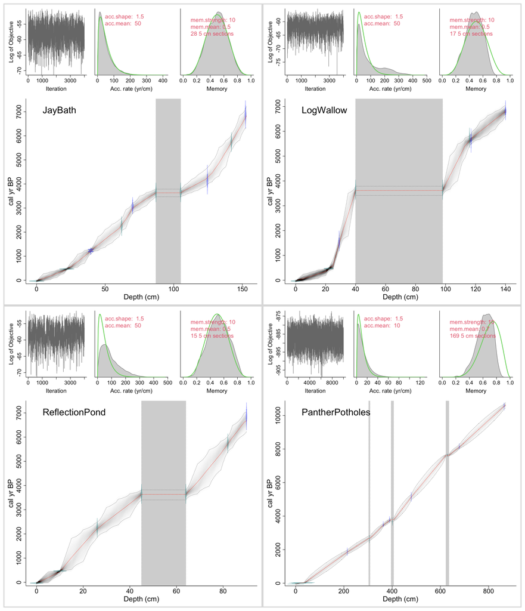

**Fig. S5. Bayesian age–depth models for the Jay Bath, Log Wallow, and Reflection Pond cores at MORA and the Panther Potholes core at NOCA.** For each core, the three upper panels show, from left to right, the Markov chain Monte Carlo trace, the prior (green) and posterior (grey) distributions of sediment accumulation time, and the prior and posterior distributions of memory. In the main panels, depth increases along the x-axis and age is expressed as calibrated years before present. Coloured distributions at dated depths represent the chronological controls and their uncertainty. The grey field represents the posterior distribution of possible age–depth relationships; the central red line shows the posterior age–depth estimate and the outer dotted lines the 95% posterior interval. Vertical grey bands identify tephra intervals treated as instantaneous deposition.

For Panther Potholes, we reproduced the archived Neotoma chronology as the primary model. However, Prichard et al. (2009) report uncertainties for measured ²¹⁰Pb activity, in DPM g⁻¹, and the same numerical values were entered as age errors, in years, in the archived chronology. We therefore fitted a sensitivity model in which the five ²¹⁰Pb controls were each assigned an assumed ±10-year age error, all other controls and settings unchanged (Fig. S6).

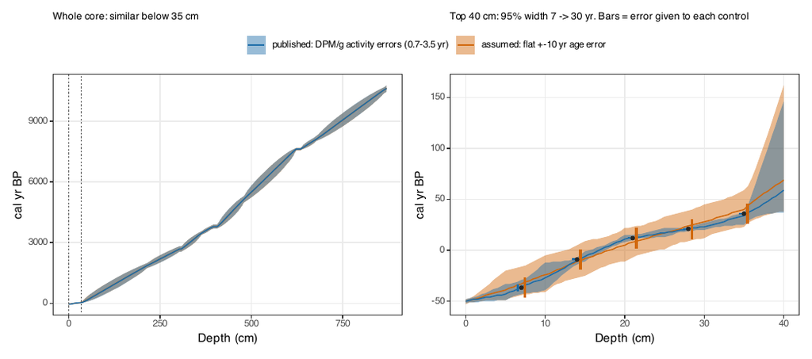

**Fig. S6. Sensitivity of the Panther Potholes age–depth chronology to uncertainty assigned to the five ²¹⁰Pb controls in the upper 35 cm of the core.** The left panel shows that the two posterior chronologies are nearly identical below the ²¹⁰Pb-dated section, whereas the right panel shows the expected increase in uncertainty within the upper 35–40 cm. The uncertainty assigned to the ²¹⁰Pb controls affects the precision of the most recent chronology but does not materially alter the deeper Holocene chronology used in our analyses.

**Chronology details →** 03_chronology (every control and its source).

# Appendix S2. Reconstruction and classification of fire histories

### S2.1 Holocene charcoal records

For MORA, we reconstructed Holocene fire activity using the Sunrise Lake, Shadow Lake, and Little Sunrise Lake macrocharcoal records from Walsh et al. (2017). These records provide evidence of regional fire activity on Sunrise Ridge and are independent of the Jay Bath, Log Wallow, and Reflection Pond records used to reconstruct vegetation. For NOCA, we reconstructed Holocene fire activity using the Panther Potholes macrocharcoal record of Prichard et al. (2009), extracted from the archived Neotoma record and dated with the Panther Potholes chronology of Appendix S1. Thus, at NOCA fire and vegetation records share the same core and chronology.

### S2.2 Identification of individual fire events

We reconstructed the fire-event detection analyses of Walsh et al. (2017) and Prichard et al. (2009) within a common workflow implemented with the R package tapas (`R/pipeline/08_fire_records.R`). CHAR was interpolated to regular intervals, its slowly varying background estimated by robust LOWESS, and candidate fire events identified where the residual peak component exceeded a record-specific threshold of the background noise. Candidates were screened with a 75-year minimum-count test (p ≤ 0.05), and consecutive exceedances were treated as one event. Record-specific settings are given in Table S2.1.

**Table S2.1. Parameters used to reconstruct individual Holocene fire events.** All records were also screened with the same 75-year minimum-count test (p ≤ 0.05). MORA settings follow Walsh et al. (2017) and Panther Potholes settings Prichard et al. (2009), except its 12-year interpolation interval, the median resolution of our updated chronology.

| Site | Fire record | Interpolation interval (years) | Background window (years) | Peak threshold | Accepted fire events |
| --- | --- | --- | --- | --- | --- |
| MORA | Sunrise Lake | 48 | 800 | 95% | 17 |
| MORA | Shadow Lake | 47 | 1000 | 95% | 14 |
| MORA | Little Sunrise Lake | 42 | 500 | 95% | 13 |
| NOCA | Panther Potholes | 12 | 500 | 99% | 66 |

<sub>Table file: table_S2_1_fire_detection_parameters.csv</sub>

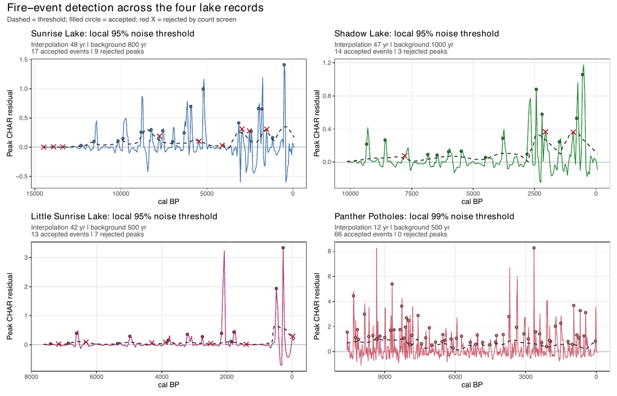

**Fig. S7. Identification of Holocene fire events in the four records.** The residual peak component is the difference between interpolated charcoal accumulation rates (CHAR) and the background estimated with the record’s robust LOWESS window. Candidate events exceed the local noise threshold (dashed line) and are then screened with a 75-year minimum-count test (p ≤ 0.05): filled circles are accepted events, red crosses rejected candidates. The manuscript example is Little Sunrise Lake (lower left; 500-year background, 95th percentile).

### S2.3 Identification of high-fire periods

We calculated fire-event frequency within centered 1,000-year windows evaluated every 100 years, normalized each record by its own maximum, averaged the normalized MORA records wherever at least two were available, and identified high-fire periods separately for each site with

**High-fire threshold = median + 1.4826 × MAD (Eq. 1)**

where MAD is the median absolute deviation of the normalized site-level fire-frequency series. Consecutive above-threshold dates form one high-fire period; gaps are not bridged and no minimum duration is imposed (`R/pipeline/11_climate_eras_high_fire.R`; worked example in **Worked examples →** 09_worked_examples).

**High-fire periods identified by Eq. 1.**

| Site | Older (cal BP) | Younger (cal BP) | Duration (years) | Maximum normalized frequency | Threshold |
| --- | --- | --- | --- | --- | --- |
| MORA | 750 | 650 | 100 | 0.67 | 0.61 |
| MORA | 2650 | 1550 | 1100 | 0.89 | 0.61 |
| MORA | 2950 | 2750 | 200 | 0.67 | 0.61 |
| MORA | 6850 | 6350 | 500 | 0.78 | 0.61 |
| MORA | 7150 | 7050 | 100 | 0.67 | 0.61 |
| NOCA | 950 | 650 | 300 | 0.73 | 0.68 |
| NOCA | 2250 | 2150 | 100 | 0.73 | 0.68 |
| NOCA | 2450 | 2350 | 100 | 0.73 | 0.68 |
| NOCA | 8650 | 7550 | 1100 | 1.00 | 0.68 |
| NOCA | 9150 | 9050 | 100 | 0.73 | 0.68 |
| NOCA | 9850 | 9650 | 200 | 0.73 | 0.68 |

<sub>Table file: high_fire_periods.csv</sub>

### S2.4 Reproducibility against the original studies

We compared the number of events identified by tapas with those reported by Walsh et al. (2017) and Prichard et al. (2009), and additionally reproduced the MORA analyses with CharAnalysis R 2.0.3 (Table S2.2). Event counts differed from the published values, including with CharAnalysis, suggesting that discrepancies arise partly from differences between software implementations. We retained tapas for one consistent detection procedure across all four records, preserving their source-specific settings rather than tuning parameters to reproduce published counts.

**Table S2.2. Holocene fire-event counts reported in the original studies and reconstructed with CharAnalysis R 2.0.3 (MORA only) and tapas (all four records).**

| Site | Lake | Published | CharAnalysis R 2.0.3 | tapas | Difference from published |
| --- | --- | --- | --- | --- | --- |
| MORA | Sunrise | 24 | 15 | 17 | -7 (-29%) |
| MORA | Shadow | 18 | 16 | 14 | -4 (-22%) |
| MORA | Little Sunrise | 16 | 14 | 13 | -3 (-19%) |
| MORA total |  | 58 | 45 | 44 | -14 (-24%) |
| NOCA | Panther Potholes | 59 | — | 66 | +7 (+12%) |
| Both sites |  | 117 | — | 110 | -7 (-6%) |

<sub>Table file: table_S2_2_fire_event_counts.csv</sub>

**Fire details →** 04_fire (per-record detection, CharAnalysis reproduction, modern fire assignment of the survey plots).

# 3. Species selection

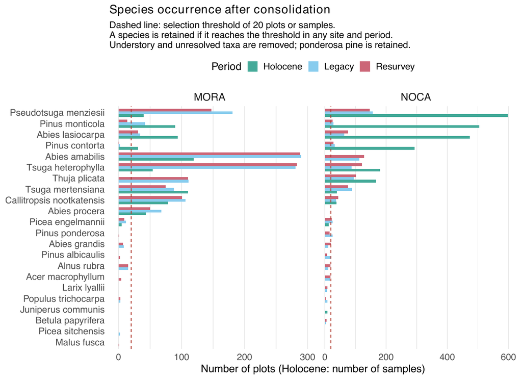

**Fig. S8. Species occurrence frequencies across sites and periods before CCA species selection.** Number of plots (legacy surveys and resurveys) or macrofossil samples (Holocene) in which each tree species was recorded at MORA and NOCA, following taxonomic harmonization and exclusion of understory and unidentified taxa. Presence was determined from both adult tree and seedling records. The dashed red line indicates the minimum occurrence threshold of 20 plots or samples. Species were retained if they reached this threshold in at least one site and period combination, resulting in 14 species included in the CCA.

**Species-selection details →** 05_species_selection (consolidation rules, excluded taxa, occupancy through time).

# 4. Climate eras and high-fire periods

Holocene climate change is classified into eras of climate change and relative stability from signed, calibration-standardized 1,000-year changes of the CCA climate variables; fire is classified independently (S2.3). Both feed Figure 2.

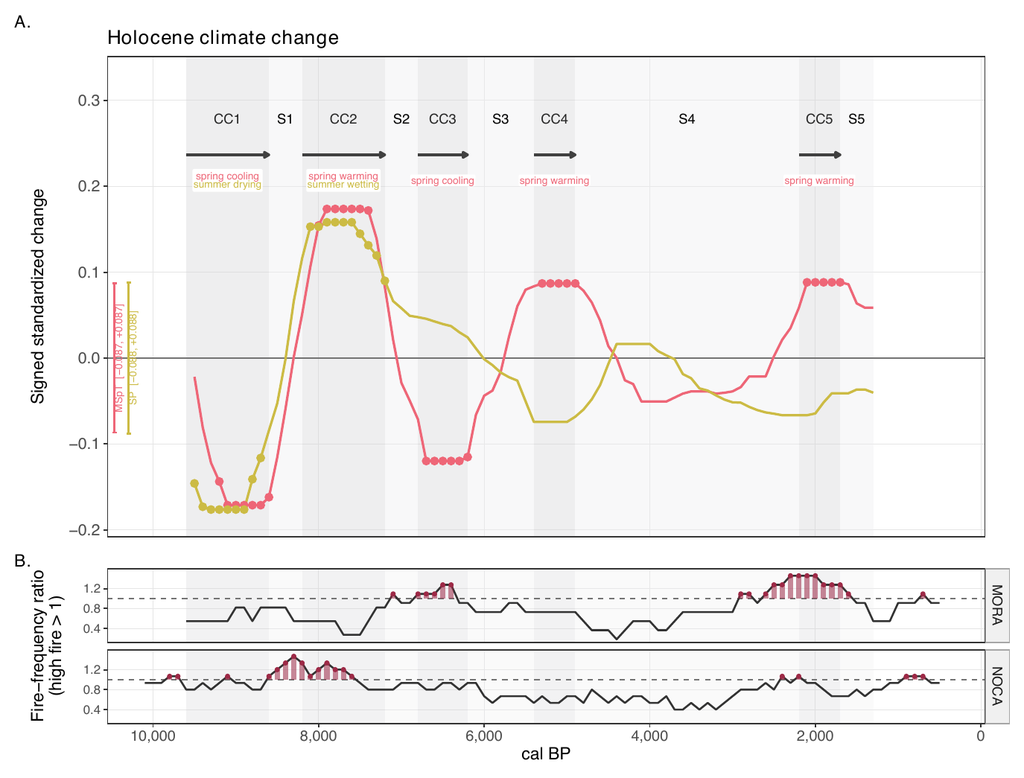

**Figure 2. Climate eras, climate-change rates and high-fire periods** (manuscript Figure 2).

**Climate eras.**

| Era | Class | Older (cal BP) | Younger (cal BP) | Active variables |
| --- | --- | --- | --- | --- |
| CC1 | climate change | 9600 | 8600 | spring cooling;summer drying |
| S1 | relative stability | 8600 | 8200 | — |
| CC2 | climate change | 8200 | 7200 | spring warming;summer wetting |
| S2 | relative stability | 7200 | 6800 | — |
| CC3 | climate change | 6800 | 6200 | spring cooling |
| S3 | relative stability | 6200 | 5400 | — |
| CC4 | climate change | 5400 | 4900 | spring warming |
| S4 | relative stability | 4900 | 2200 | — |
| CC5 | climate change | 2200 | 1700 | spring warming |
| S5 | relative stability | 1700 | 1300 | — |

<sub>Table file: climate_eras.csv</sub>

# 5. Canonical correspondence analysis

One CCA is fitted to the legacy composition of the 607 matched plots (MORA and NOCA pooled), constrained by the climate variables above (scaling 1, Hill = FALSE). Resurvey plots and Holocene samples are projected into it: their climate gives a predicted (LC) position and their composition an observed (WA) position.

```r
# R/pipeline/10_cca.R
cca_formula = reformulate(CCA_VARIABLES, response = "species_past_final")
cca_model = cca(cca_formula, data = env_past_final)
```

```r
# R/pipeline/10_cca.R
predicted_present = predict(cca_model, newdata = env_present_final, type = "lc", scaling = cca_scaling, hill = cca_hill)
projected_present = predict(cca_model, newdata = species_present_final,
                            type = "wa", scaling = cca_scaling, hill = cca_hill)

predicted_paleo = predict(cca_model, newdata = env_paleo[, CCA_VARIABLES, drop = FALSE],
                          type = "lc", scaling = cca_scaling, hill = cca_hill)
projected_paleo = predict(cca_model, newdata = species_paleo[, keep_species, drop = FALSE],
                          type = "wa", scaling = cca_scaling, hill = cca_hill)
```

**CCA axes.** Constrained inertia: 12.8% of the total.

| Axis | Eigenvalue | % total inertia | % constrained inertia |
| --- | --- | --- | --- |
| CCA1 | 0.293 | 8.442 | 65.829 |
| CCA2 | 0.152 | 4.382 | 34.171 |

<sub>Table file: cca_axes.csv</sub>

**Permutation tests** (9,999 permutations, unrestricted and restricted within parks).

| Test | Component | df | Pseudo-F | p (unrestricted) | p (within parks) |
| --- | --- | --- | --- | --- | --- |
| Overall | Model | 2 | 44.427 | 0 | 0 |
| Axis | CCA1 | 1 | 58.492 | 0 | 0 |
| Axis | CCA2 | 1 | 30.499 | 0 | 0 |

<sub>Table file: cca_permutation_tests.csv</sub>

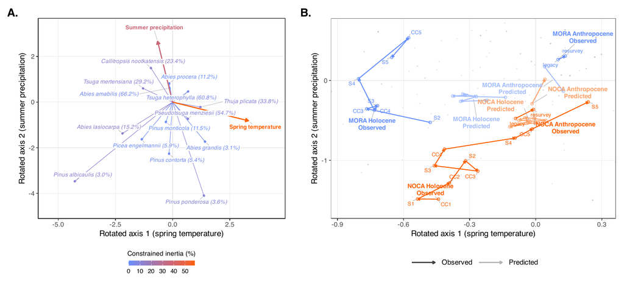

**Figure 3. Observed and climate-predicted community trajectories** (manuscript Figure 3).

**CCA details →** 06_cca (full model output, species and climate contributions, scaling 1 against scaling 2).

# 6. Tracking metrics

For every transition (Holocene: consecutive native centuries of a lake; Anthropocene: legacy to resurvey of a plot) the observed (WA) and climate-predicted (LC) positions give the community displacement, the predicted displacement, the lag between them and its change, the tracking ratio and the angle between the two directions (`R/pipeline/12_tracking.R`).

```r
# R/helpers/tracking_metrics.R
  ox = x$o1_2-x$o1; oy = x$o2_2-x$o2
  px = x$p1_2-x$p1; py = x$p2_2-x$p2
  a = sqrt(ox^2+oy^2); b = sqrt(px^2+py^2)
  x$finite_endpoints = rowSums(!is.finite(as.matrix(x[coords]))) == 0L
  x$small_observed_movement = is.finite(a) & a <= epsilon
  x$small_predicted_movement = is.finite(b) & b <= epsilon
  observed_direction = x$finite_endpoints & is.finite(a) & a > epsilon
  predicted_direction = x$finite_endpoints & is.finite(b) & b > epsilon
  x$angle_valid = observed_direction & predicted_direction
  x$pace_counterfactual_valid = observed_direction
  x$direction_counterfactual_valid = predicted_direction
  x$tracking_ratio_valid = predicted_direction
  x$delta_observed_CCA1 = ox; x$delta_observed_CCA2 = oy
  x$delta_predicted_CCA1 = px; x$delta_predicted_CCA2 = py
  x$observed_vegetation_displacement = a
  x$predicted_vegetation_displacement = b
  x$observed_turnover_rate = a/x$vegetation_dt_years*100
  x$predicted_vegetation_change_rate = b/x$climate_dt_years*100
  x$magnitude_tracking_ratio = ifelse(predicted_direction, a/b, NA_real_)
  x$rate_tracking_ratio = ifelse(predicted_direction,
    x$observed_turnover_rate/x$predicted_vegetation_change_rate, NA_real_)
  x$angle_degrees = acos(safe_cosine_2d(ox, oy, px, py, epsilon))*180/pi
  x$lag_t1 = sqrt((x$o1-x$p1)^2+(x$o2-x$p2)^2)
  x$lag_t2 = sqrt((x$o1_2-x$p1_2)^2+(x$o2_2-x$p2_2)^2)
  x$change_in_lag = x$lag_t2-x$lag_t1
  x$lag_rate_per_century = x$change_in_lag/x$climate_dt_years*100
```

```r
# R/helpers/tracking_metrics.R
  x$pace_corrected_CCA1 = x$pace_corrected_CCA2 = rep(NA_real_, nrow(x))
  x$direction_corrected_CCA1 = x$direction_corrected_CCA2 = rep(NA_real_, nrow(x))
  i = observed_direction
  x$pace_corrected_CCA1[i] = x$o1[i]+b[i]*ox[i]/a[i]
  x$pace_corrected_CCA2[i] = x$o2[i]+b[i]*oy[i]/a[i]
  i = predicted_direction
  x$direction_corrected_CCA1[i] = x$o1[i]+a[i]*px[i]/b[i]
  x$direction_corrected_CCA2[i] = x$o2[i]+a[i]*py[i]/b[i]
  x$lag_t2_pace_corrected = sqrt((x$pace_corrected_CCA1-x$p1_2)^2+
    (x$pace_corrected_CCA2-x$p2_2)^2)
  x$lag_t2_direction_corrected = sqrt((x$direction_corrected_CCA1-x$p1_2)^2+
    (x$direction_corrected_CCA2-x$p2_2)^2)
  x$pace_effect_on_lag = x$lag_t2-x$lag_t2_pace_corrected
  x$direction_effect_on_lag = x$lag_t2-x$lag_t2_direction_corrected
  x$pace_effect_on_lag_per_century = x$pace_effect_on_lag/x$climate_dt_years*100
  x$direction_effect_on_lag_per_century = x$direction_effect_on_lag/x$climate_dt_years*100
```

**Holocene transitions per lake.**

| Site | Lake | Occupied centuries | Transitions | Gaps > 100 yr | Median duration (yr) | Longest (yr) |
| --- | --- | --- | --- | --- | --- | --- |
| MORA | JayBath | 44 | 43 | 15 | 100 | 400 |
| MORA | LogWallow | 35 | 34 | 15 | 100 | 600 |
| MORA | ReflectionPond | 27 | 26 | 23 | 200 | 600 |
| NOCA | PantherPotholes | 108 | 107 | 0 | 100 | 100 |

<sub>Table file: holocene_lake_support.csv</sub>

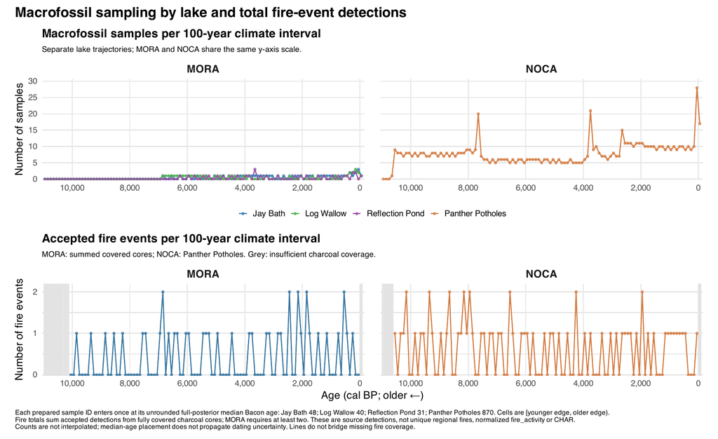

**Fig. S9. Holocene sampling support.** Macrofossil samples and accepted fire events on the native 100-year climate intervals.

**Tracking details →** 07_tracking (output schema, transition displays, species and climate contributions).

# 7. Era models

Each tracking response is compared between the Holocene and the Anthropocene with a GLS with an era × site mean structure and era-by-site variances. Holocene transitions of a lake are neighbours in time: the primary residual structure is MA(1) within each lake series, compared with independent and continuous-time AR(1) residuals on identical observations.

```r
# R/helpers/reconstruction_models.R
reconstruction_correlation = function(type) switch(type,
  Independent=NULL,MA1=nlme::corARMA(p=0,q=1,form=~time_index | series),
  CAR1=nlme::corCAR1(form=~time_centuries | series),stop('Unknown covariance family'))
```

```r
# R/helpers/reconstruction_models.R
  fit=nlme::gls(fixed,data=d,correlation=reconstruction_correlation(type),
    weights=if(is.null(variance)) NULL else nlme::varIdent(form=as.formula(paste('~1 |',variance))),method='REML',
    na.action=na.fail,control=nlme::glsControl(msMaxIter=300))
```

```r
# R/pipeline/13_era_models.R
  entry=reconstruction_select(selected$data,estimate~era*site,variance='era_site')
  if(is.null(entry$fit)) stop('All combined-era covariance fits failed: ',metric)
  entry$metric=metric;entry$era='Combined';entry$specification='era_by_site'
  results_dir=file.path(out('era_comparison'),metric)
  tables=reconstruction_export(list(primary=entry),results_dir,selected$excluded)
  means=emmeans(entry$fit,~era | site,data=entry$data,mode='satterthwaite')
  mt=as.data.frame(summary(means,infer=c(TRUE,FALSE)))
  group_means=as_tibble(mt) |> transmute(metric=metric,model_type=entry$selected,site,era,
    estimate=emmean,std_error=SE,df,conf_low=lower.CL,conf_high=upper.CL,
    n=map2_int(as.character(site),as.character(era),~sum(entry$data$site==.x & entry$data$era==.y)))
  ct=as.data.frame(summary(contrast(means,method=list('Anthropocene - Holocene'=c(-1,1))),
    infer=c(TRUE,TRUE),adjust='none'))
```

**Anthropocene − Holocene contrasts by response and park.**

| Response | Site | Anthropocene − Holocene | SE | 95% CI low | 95% CI high | p | Covariance |
| --- | --- | --- | --- | --- | --- | --- | --- |
| direction_effect_on_lag_per_century | MORA | 0.249 | 0.066 | 0.119 | 0.380 | 0.000 | MA1 |
| direction_effect_on_lag_per_century | NOCA | -0.130 | 0.123 | -0.371 | 0.111 | 0.290 | MA1 |
| lag_rate_per_century | MORA | 0.528 | 0.061 | 0.409 | 0.648 | 0.000 | MA1 |
| lag_rate_per_century | NOCA | -0.074 | 0.141 | -0.352 | 0.204 | 0.599 | MA1 |
| observed_turnover_rate | MORA | 0.757 | 0.049 | 0.659 | 0.854 | 0.000 | MA1 |
| observed_turnover_rate | NOCA | 1.839 | 0.116 | 1.610 | 2.068 | 0.000 | MA1 |
| pace_effect_on_lag_per_century | MORA | 0.154 | 0.047 | 0.060 | 0.247 | 0.001 | MA1 |
| pace_effect_on_lag_per_century | NOCA | -0.278 | 0.143 | -0.560 | 0.004 | 0.054 | MA1 |
| standardized_climate_change_rate | MORA | 2.448 | 0.048 | 2.354 | 2.543 | 0.000 | MA1 |
| standardized_climate_change_rate | NOCA | 2.544 | 0.116 | 2.315 | 2.772 | 0.000 | MA1 |

<sub>Table file: era_contrasts.csv</sub>

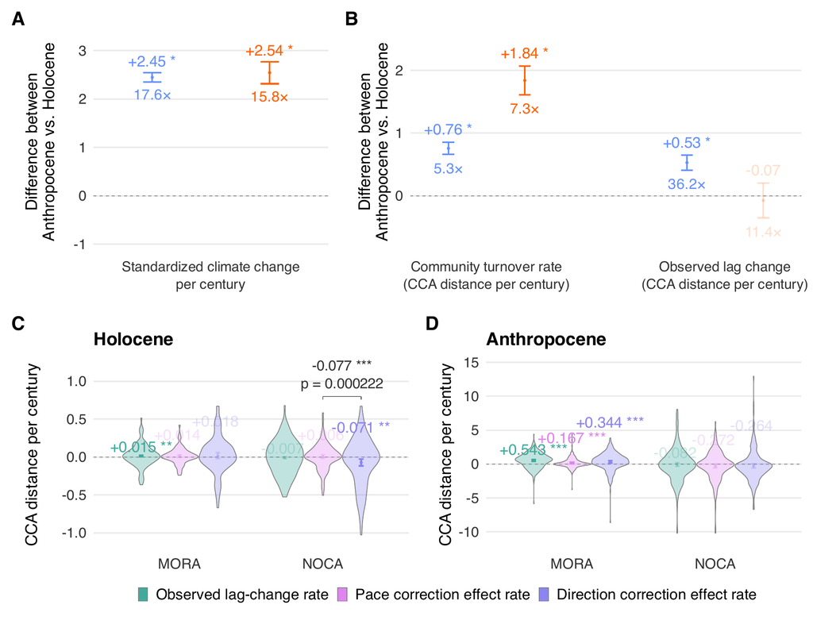

**Figure 4. Era contrasts, observed lag change and correction effects** (manuscript Figure 4).

The pace and direction correction effects of a transition are estimated jointly, with a paired MA(1) structure that keeps the two effects of the same transition correlated:

```r
# R/pipeline/13_era_models.R
  fit=gls(estimate~era*site*correction,data=d,correlation=corPairedMA1(),
    weights=varIdent(form=~1 | era_site_correction),method='REML',na.action=na.fail,
    control=glsControl(msMaxIter=500))
```

**Model details →** 08_models (covariance comparison, coefficients, residual checks and individual-lake checks for every response).

# 8. Climate and fire predictors within eras

Within each era, lag change and the correction effects are related to site, the climate-change rate and fire (Holocene: fire activity; Anthropocene: burned plots).

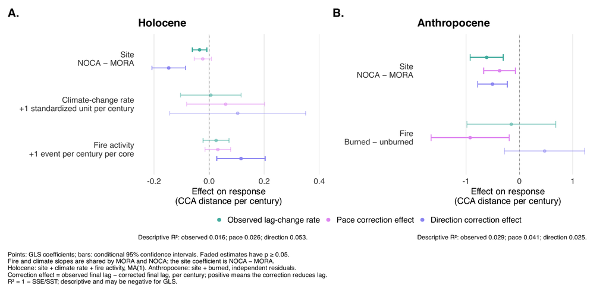

```r
# R/helpers/reconstruction_models.R
  if(era=='Holocene') {
    if('burned' %in% names(d)) d$burned=factor(rep(NA_character_,nrow(d)),levels=c('Unburned','Burned'))
    d$series=paste('H',d$site,d$lake,sep='_')
    d$time_index=d$transition_index;d$time_centuries=-d$interval_mid_cal_bp/100
    fixed=estimate~site+climate_rate+fire_activity
  } else {
    d$series=paste('A',d$site,d$plot_id,sep='_');d$time_index=0L;d$time_centuries=0
    d$burned=factor(d$burned,levels=c(FALSE,TRUE),labels=c('Unburned','Burned'))
    fixed=if(extended) estimate~site+elevation+climate_rate+burned else estimate~site+burned
  }
```

**Figure 5. Site, climate and fire effects on lag-change rates by era** (manuscript Figure 5).

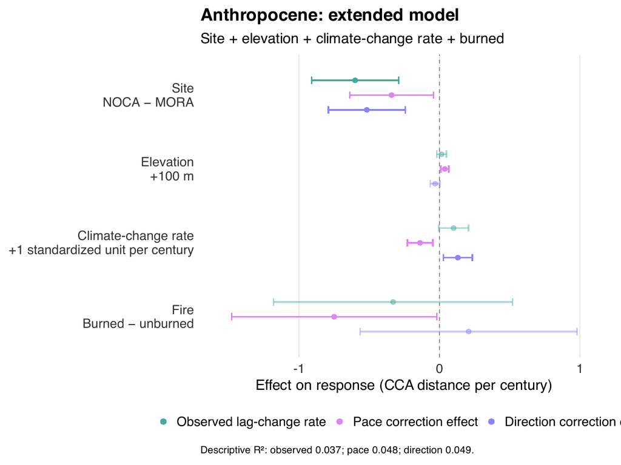

**Fig. S10. Extended Anthropocene predictor model** (site + elevation + climate-change rate + burned).

# 9. Species and seasonal-climate contributions

Each CCA displacement is split exactly into species contributions and seasonal-climate contributions (`R/pipeline/15_contributions.R`).

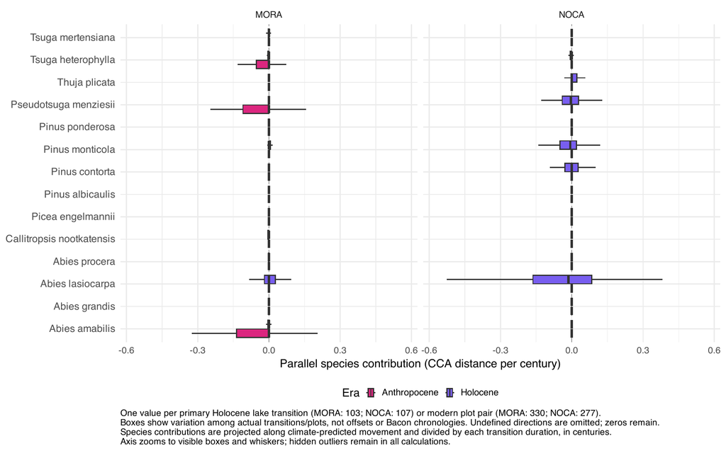

**Fig. S11. Species contributions to community displacement, by era and park.**

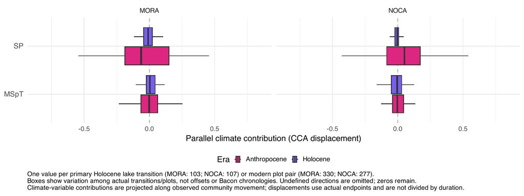

**Fig. S12. Seasonal-climate contributions to predicted displacement, by era and park.**

**Contribution details →** 07_tracking.

# 10. Limitations and open questions

The chronology controls and adopted uncertainty assumptions were reconsidered and retained on 2026-10-06. They no longer require a decision for the current analysis. Conditional uncertainty, assumed errors and the unverified basal-lahar correlation remain interpretation limits documented above and in the MORA source notes; any future chronology revision is separate work.

[output not shown]